# Challenge 1

Pablo Barbera

May 19, 2016

#### Descriptive analyses of text

Write code in R that help you answer the following questions. We’ll be working with a dataset that contains all the tweets sent by Donald Trump, Ted Cruz, Hillary Clinton, and Bernie Sanders during the 2016 primary election campaign.

1. Read the data. The name of the candidate is in the `screen_name` variable. How many tweets has each of the candidate sent?

```r
library(quanteda)
tweets <- read.csv('../datasets/candidate-tweets.csv', stringsAsFactors=F)
table(tweets$screen_name)
```

```
##
##   BernieSanders  HillaryClinton realDonaldTrump         tedcruz
##            4025            5715            7546            9449
```

2. How many tweets contain a hashtag? What are the most popular hashtags by candidate? Who are the most mentioned handles by candidate?

```r
length(grep('#', tweets$text))
```

```
## [1] 9945
```

```r
# find the N most common hashtags in a string vector
getCommonHashtags <- function(text, n=20){
    hashtags <- regmatches(text, gregexpr("#(\\d|\\w)+",text))
    hashtags <- unlist(hashtags)
    tab <- table(hashtags)
    return(head(sort(tab, dec=TRUE), n=n))
}

# find the N most common handles in a string vector
getCommonHandles <- function(text, n=20){
    handles <- regmatches(text, gregexpr('@([0-9_A-Za-z]+)',text, perl=TRUE))
    handles <- unlist(handles)
    tab <- table(handles)
    return(head(sort(tab, dec=TRUE), n=n))
}


getCommonHashtags(tweets$text[tweets$screen_name=="realDonaldTrump"])
```

```
## hashtags
##             #Trump2016 #MakeAmericaGreatAgain             #VoteTrump
##                    659                    508                     68
##                     #1             #GOPDebate                 #Trump
##                     52                     50                     42
##                  #FITN             #DemDebate                   #GOP
##                     38                     33                     32
##            #TrumpTrain              #IACaucus             #TeamTrump
##                     31                     25                     22
##          #SuperTuesday                   #SNL             #trump2016
##                     21                     18                     18
##                 #POTUS           #DonaldTrump        #CaucusForTrump
##                     16                     14                     13
##     #TrumpForPresident         #VoteTrump2016
##                     13                     13
```

```r
getCommonHashtags(tweets$text[tweets$screen_name=="tedcruz"])
```

```
## hashtags
##                #CruzCrew               #GOPDebate              #ChooseCruz
##                     1069                      381                      301
##           #CruzToVictory             #CruzCountry                #Cruz2016
##                      233                      230                      153
##            #MakeDCListen              #FullRepeal          #CruzinToCaucus
##                      152                      140                      133
##           #CaucusForCruz              #nhpolitics        #WashingtonCartel
##                      132                       92                       89
##           #AbolishTheIRS                #iacaucus       #StopObamasAmnesty
##                       85                       80                       79
##                    #fitn #DefundPlannedParenthood                #IranDeal
##                       71                       63                       62
##                #IACaucus                     #IRS
##                       59                       59
```

```r
getCommonHashtags(tweets$text[tweets$screen_name=="HillaryClinton"])
```

```
## hashtags
##    #DemDebate  #Hillary2016    #GOPdebate    #ImWithHer  #DemTownHall
##           256           203           150           150            56
##    #GOPDebate    #603forHRC      #HillYes  #HillaryInNH        #IDPJJ
##            40            37            36            25            22
##          #TBT      #HRCinSC         #SOTU #SuperTuesday    #Beijing20
##            18            16            16            15            13
##  #StandWithPP     #DemForum         #FITN    #Periscope         #fitn
##            13            12            12            12            11
```

```r
getCommonHashtags(tweets$text[tweets$screen_name=="BernieSanders"])
```

```
## hashtags
##        #DemDebate      #FeelTheBern          #NotMeUs  #CaucusForBernie
##               123               113                56                52
## #DebateWithBernie      #DemTownHall      #SuperMonday     #VoteTogether
##                47                44                39                35
##        #BreakEmUp  #AmericaTogether       #Bernie2016     #SuperTuesday
##                30                29                28                28
##         #iacaucus      #ByThePeople      #feelthebern             #fitn
##                25                21                19                17
##       #nhpolitics       #PrimaryDay    #BirdieSanders        #NHPrimary
##                16                16                14                14
```

```r
getCommonHandles(tweets$text[tweets$screen_name=="realDonaldTrump"])
```

```
## handles
## @realDonaldTrump         @FoxNews             @CNN      @megynkelly
##             2257              277              203              143
##   @foxandfriends      @DanScavino         @JebBush     @seanhannity
##              130               95               86               75
##   @oreillyfactor     @IvankaTrump           @Macys       @EricTrump
##               73               56               55               54
##     @Morning_Joe           @greta        @KarlRove         @nytimes
##               52               47               44               44
##   @DRUDGE_REPORT      @TrumpDoral      @AnnCoulter  @DonaldJTrumpJr
##               43               42               40               40
```

```r
getCommonHandles(tweets$text[tweets$screen_name=="tedcruz"])
```

```
## handles
##         @tedcruz         @TedCruz     @TeamTedCruz         @FoxNews
##             2239              442              238              214
## @realDonaldTrump       @glennbeck      @heidiscruz   @PatrickSvitek
##              198              111              107               87
##    @CarlyFiorina   @brucereddenjr   @marklevinshow     @SteveKingIA
##               85               81               67               67
##   @GregAbbott_TX         @trscoop @catblackfrazier      @SenTedCruz
##               65               65               64               60
##     @seanhannity      @megynkelly     @betsy_klein   @GovernorPerry
##               57               54               52               52
```

```r
getCommonHandles(tweets$text[tweets$screen_name=="HillaryClinton"])
```

```
## handles
##  @HillaryClinton @TheBriefing2016    @HillaryforNH    @HillaryforIA
##              503              253              135              101
##     @billclinton    @HillaryforSC           @POTUS     @mayaharris_
##               80               74               67               59
##    @HillaryforNV  @ChelseaClinton     @johnpodesta      @Ann_OLeary
##               51               39               30               29
## @realDonaldTrump             @HFA  @hillaryclinton   @BernieSanders
##               28               26               22               21
##         @LSD_Esq       @katyperry   @rosenbergerlm   @lorellapraeli
##               20               18               18               16
```

```r
getCommonHandles(tweets$text[tweets$screen_name=="BernieSanders"])
```

```
## handles
##   @BernieSanders  @HillaryClinton           @MSNBC       @cascamike
##              542               86               33               23
##          @MoveOn      @BenJealous  @maryaliceparks    @ErikaAndiola
##               22               21               21               19
##   @berniesanders     @Morning_Joe   @People4Bernie     @ThisWeekABC
##               17               17               16               14
##     @UniPolitica    @WPJohnWagner        @kartpath    @TulsiGabbard
##               14               14               13               13
##     @ABCPolitics      @KillerMike @realDonaldTrump         @CNNSotu
##               12               12               12               11
```

3. Pick two candidates and create a corpus object for each of them. Find the most common collocations for each. Compute their average readability scores.

```r
# collocations
trump <- corpus(tweets$text[tweets$screen_name=="realDonaldTrump"])
collocations(trump)[1:20,]
```

```
##                      word1       word2 word3 count        G2
##  1:                  thank         you         682 5773.4601
##  2:                   will          be         508 3423.3063
##  3:                 donald       trump         348 2784.4910
##  4:                  great       again         313 2649.2330
##  5:                   make     america         273 2539.3753
##  6:                america       great         272 2114.1454
##  7:             #trump2016       https         258 1743.4658
##  8:                      i          am         208 1561.7983
##  9: #makeamericagreatagain  #trump2016         164 1487.4973
## 10:                    ted        cruz         115 1441.1296
## 11:                      i        will         306 1365.2752
## 12:                    new   hampshire         105 1189.6230
## 13:                  south    carolina          76 1133.5690
## 14:                     we        need         134 1129.0653
## 15:                    jeb        bush          80  923.9651
## 16:                hillary     clinton          79  916.5521
## 17:                     be interviewed         104  874.7739
## 18:                    our     country         105  846.2226
## 19:                  marco       rubio          63  820.6395
## 20:                     of         the         341  815.7586
```

```r
clinton <- corpus(tweets$text[tweets$screen_name=="HillaryClinton"])
collocations(clinton)[1:20,]
```

```
##        word1            word2 word3 count        G2
##  1:       rt @thebriefing2016         240 1874.4935
##  2:       we             need         262 1867.7679
##  3:   donald            trump          94 1204.7595
##  4:       if              you         167 1138.0358
##  5:      gun         violence          96 1133.9633
##  6:   health             care          94 1036.4982
##  7:   should               be         118  828.3308
##  8:    thank              you          87  794.8987
##  9:     need               to         198  790.9224
## 10:     wall           street          51  772.2116
## 11:      new        hampshire          64  764.6134
## 12:       rt    @hillaryfornh         106  739.6916
## 13:  planned       parenthood          43  724.5761
## 14:       we              can         132  718.2520
## 15:    equal              pay          51  624.3309
## 16:  hillary          clinton          80  606.1508
## 17:    white            house          44  597.3388
## 18:  supreme            court          35  581.8124
## 19:    watch             live          56  550.5324
## 20: fighting              for          78  514.0615
```

```r
# readability
fk <- readability(trump, "Flesch.Kincaid")
mean(fk)
```

```
## [1] 7.776955
```

```r
fk <- readability(clinton, "Flesch.Kincaid")
mean(fk)
```

```
## [1] 6.800205
```

4. Now create a dfm object for each candidate and look at the most frequent features for each of them. Then compute the lexical diversity.

```r
trumpdfm <- dfm(trump, ignoredFeatures = c(stopwords("english"), "t.co", "https", "rt", "amp", "http", "t.c", "can", "u"), ngrams=c(1,3))
```

```
## Creating a dfm from a corpus ...
##    ... lowercasing
##    ... tokenizing
##    ... indexing documents: 7,546 documents
##    ... indexing features: 108,585 feature types
##    ... removed 77,848 features, from 182 supplied (glob) feature types
##    ... created a 7546 x 30737 sparse dfm
##    ... complete.
## Elapsed time: 2.756 seconds.
```

```r
topfeatures(trumpdfm)
```

```
##       @realdonaldtrump                  trump                   will
##                   2278                   1549                   1160
##                  great                  thank                america
##                   1117                    701                    559
## #makeamericagreatagain                 donald                   just
##                    519                    509                    487
##                   make
##                    412
```

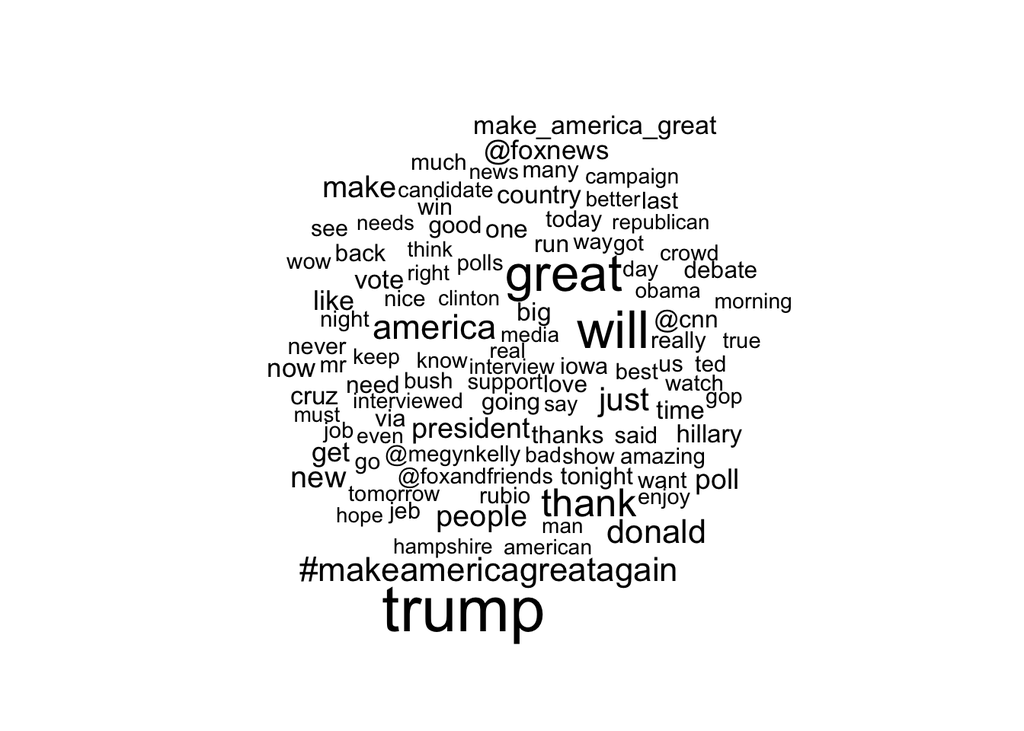

```r
plot(trumpdfm, rot.per=0, scale=c(3.5, .75), max.words=100)
```

```r
clintondfm <- dfm(clinton, ignoredFeatures = c(stopwords("english"), "t.co", "https", "rt", "amp", "http", "t.c", "can", "u", "s", "h"), ngrams=c(1,3))
```

```
## Creating a dfm from a corpus ...
##    ... lowercasing
##    ... tokenizing
##    ... indexing documents: 5,715 documents
##    ... indexing features: 88,339 feature types
##    ... removed 65,017 features, from 184 supplied (glob) feature types
##    ... created a 5715 x 23322 sparse dfm
##    ... complete.
## Elapsed time: 2.172 seconds.
```

```r
topfeatures(clintondfm)
```

```
##         hillary @hillaryclinton            need       president
##            1402             470             373             323
##            will           today            make      #demdebate
##             299             293             267             257
##           women        families
##             256             255
```

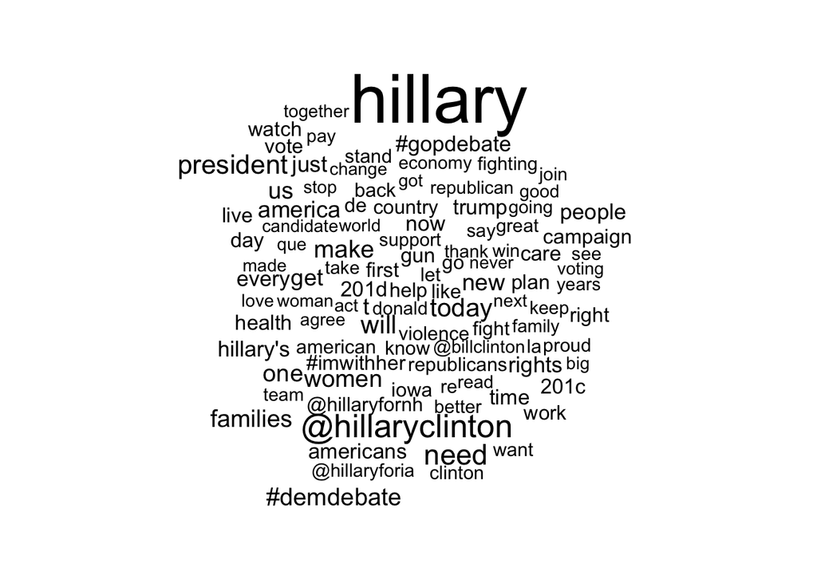

```r
plot(clintondfm, rot.per=0, scale=c(3.5, .75), max.words=100)
```

5. Compute the average sentiment score of the tweets sent by each candidate. Which candidate sent the most positive tweets? Is that what you expected? Find the most negative and most positive tweets for each candidate.

```r
tweets <- read.csv('../datasets/candidate-tweets.csv', stringsAsFactors=F)
twcorpus <- corpus(tweets$text)
# loading lexicon of positive and negative words (from Neal Caren)
lexicon <- read.csv("../datasets/lexicon.csv", stringsAsFactors=F)
pos.words <- lexicon$word[lexicon$polarity=="positive"]
neg.words <- lexicon$word[lexicon$polarity=="negative"]

# first we construct a dictionary object
mydict <- dictionary(list(negative = neg.words,
                          positive = pos.words))
# apply it to our corpus
sent <- dfm(twcorpus, dictionary = mydict)
```

```
## Creating a dfm from a corpus ...
##    ... lowercasing
##    ... tokenizing
##    ... indexing documents: 26,735 documents
##    ... indexing features: 41,179 feature types
##    ... applying a dictionary consisting of 2 keys
##    ... created a 26735 x 2 sparse dfm
##    ... complete.
## Elapsed time: 28.453 seconds.
```

```r
# and add it as a new variable
tweets$score <- as.numeric(sent[,2]) - as.numeric(sent[,1])
# loop over candidates
candidates <- c("realDonaldTrump", "HillaryClinton", "tedcruz", "BernieSanders")

for (cand in candidates){
  message(cand, " -- average sentiment: ",
      round(mean(tweets$score[tweets$screen_name==cand]), 4)
    )
}
```

```
## realDonaldTrump -- average sentiment: 0.5872
```

```
## HillaryClinton -- average sentiment: 0.4282
```

```
## tedcruz -- average sentiment: 0.4961
```

```
## BernieSanders -- average sentiment: 0.3727
```

```r
# most positive and negative tweets
tweets <- tweets[order(tweets$score),]
head(tweets)
```

```
##           screen_name
## 14386         tedcruz
## 13843         tedcruz
## 14896         tedcruz
## 15738         tedcruz
## 3672  realDonaldTrump
## 17409         tedcruz
##                                                                                                                                                             text
## 14386                 You can't win a war against radical Islamic terrorism with an Admin thats unwilling to utter the words radical Islamic terrorism" #Opp4All
## 13843                    Can't win battle against radical Islamic terrorism if you're unwilling to utter words radical Islamic terrorism https://t.co/HASzpU0kuy
## 14896                      We can't win a war against radical Islamic terrorism with a president who wont utter words radical Islamic terrorism #SCFreedomSummit
## 15738                We can't defeat radical Islamic terrorism as long as we have a Commander-in-Chief unwilling to utter the words "radical Islamic terrorism."
## 3672                Little Barry Diller, who lost a fortune on Newsweek and Daily Beast, only writes badly about me. He is a sad and pathetic figure. Lives lie!
## 17409 We cannot defeat radical Islamic terrorism with a POTUS who refuses to utter the words “radical Islamic terrorism!”\nhttps://t.co/CLOo7xkxeg
##                  datetime
```

[output cut: 20 more lines]

```r
tail(tweets)
```

```
##           screen_name
## 5809  realDonaldTrump
## 12987  HillaryClinton
## 20488         tedcruz
## 4991  realDonaldTrump
## 6955  realDonaldTrump
## 22177         tedcruz
##                                                                                                                                                                         text
## 5809                              .@AnnCoulter has been amazing. We will win and establish strong borders, we will build a WALL and Mexico will pay. We will be great again!
## 12987 Civil rights &amp; voting rights.\nWorker’s rights &amp; women’s rights.\nLGBT rights and rights for people with disabilities.\n\nLet's defend them all.
## 20488                    RT @LesaLJones: "I will not compromise your religious liberty rights. I will not compromise 2nd Amendment rights." @tedcruz/Tulsa https://t…
## 4991                                   I will be re-tweeting some of your better, most imaginative and hopefully insightful tweets. Make them good (great)! Important stuff.
## 6955                             Why can't the pundits be honest? Hopefully we are all looking for a strong and great country again. I will make it strong and great!  JOBS!
## 22177                   We will restore our spirit. We will free our minds &amp; imagination. We will create a better world. We will bring back jobs, freedom &amp; security
##                  datetime
```

[output cut: 20 more lines]

BONUS. Create a comparison plot using a single corpus object where the name of the candidates is a document variable. Check `?plot.dfm` for clues.

```r
tweets <- textfile('../datasets/candidate-tweets.csv', textField = 'text')
twcorpus <- corpus(tweets)
twcorpus <- subset(twcorpus, screen_name %in% c("BernieSanders", "HillaryClinton"))
twdfm <- dfm(twcorpus, groups="screen_name", ignoredFeatures = c(stopwords("english"), "t.co", "https", "rt", "amp", "http", "t.c", "can", "u", "s", "h"), ngrams=c(1,2))
```

```
## Creating a dfm from a corpus ...
##    ... grouping texts by variable: screen_name
##    ... lowercasing
##    ... tokenizing
##    ... indexing documents: 2 documents
##    ... indexing features: 103,582 feature types
##    ... removed 54,401 features, from 184 supplied (glob) feature types
##    ... created a 2 x 49181 sparse dfm
##    ... complete.
## Elapsed time: 2.449 seconds.
```

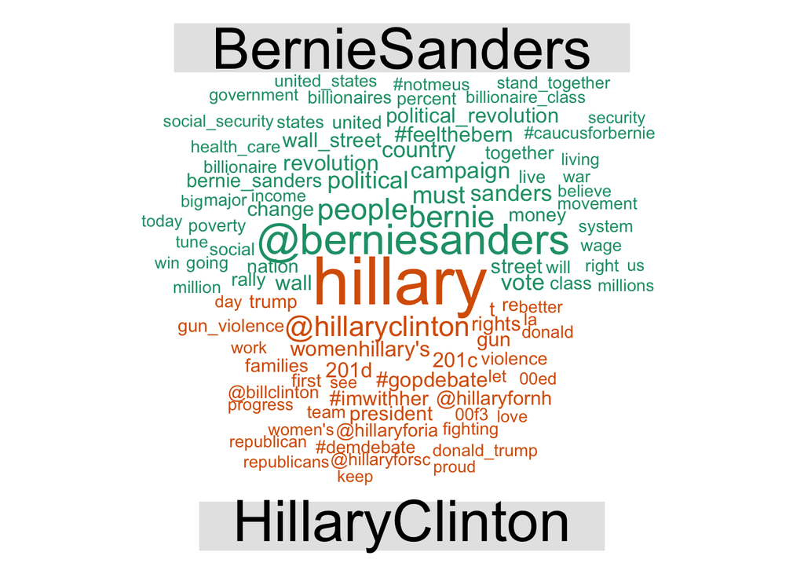

```r
plot(twdfm, comparison=TRUE, rot.per=0, scale=c(3.5, .75), max.words=100)
```